1. R in Jupyter (Python Kernal)
2. Python in Jupyter

# Intro to Juypter Notebook with R and Python

The following notebook was put together to explore the utility of pipelining R into a juypter notebook using a python kernal. I am relatively new to jupyter notebooks so please exucse any abberant nomenclature or vernacular. The first thing I decided to do, however, was practice importing a image into the notebook. The picture is of a growth model I read about when I started my masters degree at Teachers College. The conference paper and presentation were titled *Measuring Multidimensional Growth A Higher-Order IRT Perspective* by Nydick, Wang, Xiong (2014).

[figure not shown]

Below I begin to explore using R and python in a jupyter notebook. Basic statistical procedures are explored using the two different langugages. The %load_ext rpy2.ipython was necessary to use R within a python notebook. The rpy2 package needed to be installed before being able to execute %load_ext ryp2.ipython.

# R in Jupyter (Python Kernal)

```python
%load_ext rpy2.ipython
```

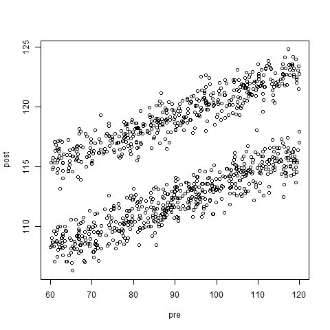

```python
%R set.seed(1234567)
%R pre <- runif(n = 1000, min = 60, max = 120)
%R female <- rbinom(n = 1000, size = 1, prob = 0.45)
%R beta0 <- 100
%R beta1 <- 0.134
%R beta2 <- 7.13
%R post <- beta0 + beta1*pre + beta2*female + rnorm(n = 1000, 0, 1)
%R sim <- as.data.frame(cbind(pre,post,female))
%R plot(pre,post)
```

```python
%R head(sim)
```

|  | pre | post | female |
| --- | --- | --- | --- |
| 1 | 93.735650 | 112.173214 | 0.0 |
| 2 | 103.589910 | 120.564384 | 1.0 |
| 3 | 114.914991 | 115.390545 | 0.0 |
| 4 | 61.781662 | 115.576545 | 1.0 |
| 5 | 106.050582 | 121.889845 | 1.0 |
| 6 | 88.803239 | 119.121884 | 1.0 |

```python
%R require(psych)
%R psych::describe(sim)
```

|  | vars | n | mean | sd | median | trimmed | mad | min | max | range | skew | kurtosis | se |
| --- | --- | --- | --- | --- | --- | --- | --- | --- | --- | --- | --- | --- | --- |
| pre | 1 | 1000.0 | 90.516210 | 16.966942 | 90.438443 | 90.630110 | 21.006287 | 60.014718 | 119.916457 | 59.901738 | -0.052430 | -1.123876 | 0.536542 |
| post | 2 | 1000.0 | 115.326338 | 4.306586 | 115.237223 | 115.279254 | 5.137293 | 106.302944 | 124.811543 | 18.508600 | 0.093132 | -0.993049 | 0.136186 |
| female | 3 | 1000.0 | 0.451000 | 0.497842 | 0.000000 | 0.438750 | 0.000000 | 0.000000 | 1.000000 | 1.000000 | 0.196653 | -1.963288 | 0.015743 |

```python
%R lm <- lm(post~ pre + female, data = sim)
%R coef <- lm$coefficients
%R as.data.frame(coef)
```

|  | coef |
| --- | --- |
| (Intercept) | 100.094873 |
| pre | 0.132721 |
| female | 7.135396 |

# Python in Jupyter

The code %R -o sim ouputs the simulated dataset sim for python to use. The dataset is renamed to dat. I could have also simulated the data in python using numpy.

```python
%R -o sim
dat = sim
```

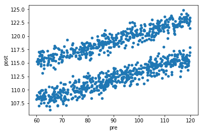

```python
import matplotlib.pyplot as plt
dat.plot(kind='scatter', x = 'pre', y = 'post')
plt.show()
```

```python
dat.head()
```

|  | pre | post | female |
| --- | --- | --- | --- |
| 1 | 93.735650 | 112.173214 | 0.0 |
| 2 | 103.589910 | 120.564384 | 1.0 |
| 3 | 114.914991 | 115.390545 | 0.0 |
| 4 | 61.781662 | 115.576545 | 1.0 |
| 5 | 106.050582 | 121.889845 | 1.0 |

```python
dat.describe()
```

|  | pre | post | female |
| --- | --- | --- | --- |
| count | 1000.000000 | 1000.000000 | 1000.000000 |
| mean | 90.516210 | 115.326338 | 0.451000 |
| std | 16.966942 | 4.306586 | 0.497842 |
| min | 60.014718 | 106.302944 | 0.000000 |
| 25% | 77.189947 | 111.812300 | 0.000000 |
| 50% | 90.438443 | 115.237223 | 0.000000 |
| 75% | 105.144405 | 118.762311 | 1.000000 |
| max | 119.916457 | 124.811543 | 1.000000 |

```python
import statsmodels.formula.api as smf
results = smf.ols('post~pre + female',data=dat).fit()
results.summary()
```

OLS Regression Results

| Dep. Variable: | post | R-squared: | 0.947 |
| --- | --- | --- | --- |
| Model: | OLS | Adj. R-squared: | 0.947 |
| Method: | Least Squares | F-statistic: | 8883. |
| Date: | Tue, 23 Jan 2018 | Prob (F-statistic): | 0.00 |
| Time: | 09:07:21 | Log-Likelihood: | -1411.1 |
| No. Observations: | 1000 | AIC: | 2828. |
| Df Residuals: | 997 | BIC: | 2843. |
| Df Model: | 2 |  |  |
| Covariance Type: | nonrobust |  |  |

|  | coef | std err | t | P>\|t\| | [0.025 | 0.975] |
| --- | --- | --- | --- | --- | --- | --- |
| Intercept | 100.0949 | 0.173 | 577.799 | 0.000 | 99.755 | 100.435 |
| pre | 0.1327 | 0.002 | 71.622 | 0.000 | 0.129 | 0.136 |
| female | 7.1354 | 0.063 | 112.983 | 0.000 | 7.011 | 7.259 |

| Omnibus: | 1.580 | Durbin-Watson: | 2.024 |
| --- | --- | --- | --- |
| Prob(Omnibus): | 0.454 | Jarque-Bera (JB): | 1.631 |
| Skew: | -0.068 | Prob(JB): | 0.442 |
| Kurtosis: | 2.856 | Cond. No. | 509. |